# State MSM Profile: **Pennsylvania**

### Background & Methods

In 2015-2016, researchers at Emory University partnered with colleagues at the Centers for Disease Control and Prevention (CDC) to develop methods to estimate the number of men who have sex with men (MSM) residing in each county in the United States. Using population and housing data from the [American Community Survey](https://www.census.gov/programs-surveys/acs/) and estimates from two peer-reviewed publications ([Oster et al., 2015](http://www.ncbi.nlm.nih.gov/pubmed/26115985) & [Purcell et al., 2012](http://www.ncbi.nlm.nih.gov/pubmed/23049658)), they derived an indirect estimate of MSM population sizes that took into account both the urbanicity of the county as well as its density of households with a male householder and a male same-sex partner.

The full methodology is published in the *Journal of Medical Internet Research - Public Health and Surveillance*:

> [Grey JA, Bernstein KT, Sullivan PS, Purcell DW, Chesson HW, Gift TL, Rosenberg ES. Estimating the population sizes of men who have sex with men in US states and counties using data from the American Community Survey. JMIR Public Health Surveill 2016;2(1):e14. DOI: 10.2196/publichealth.5365](http://publichealth.jmir.org/2016/1/e14/)

### Overview of MSM in Pennsylvania

An estimated **162,744** men who have sex with men (MSM) resided in Pennsylvania in 2013, representing 3.6% of the 4,503,084 MSM in the United States. Of the 4,798,340 adult men of Pennsylvania, 3.4% had had sex with another man in the past 5 years, which was less than the overall percentage of adult men in the United States who were MSM (3.9%).

Most MSM in Pennsylvania resided in central counties of large metropolitan areas (37.0%). Including both central and fringe counties, 69.6% resided in a large metropolitan area.

##### **Percentage of MSM by urbanicity, United States and Pennsylvania, 2013**

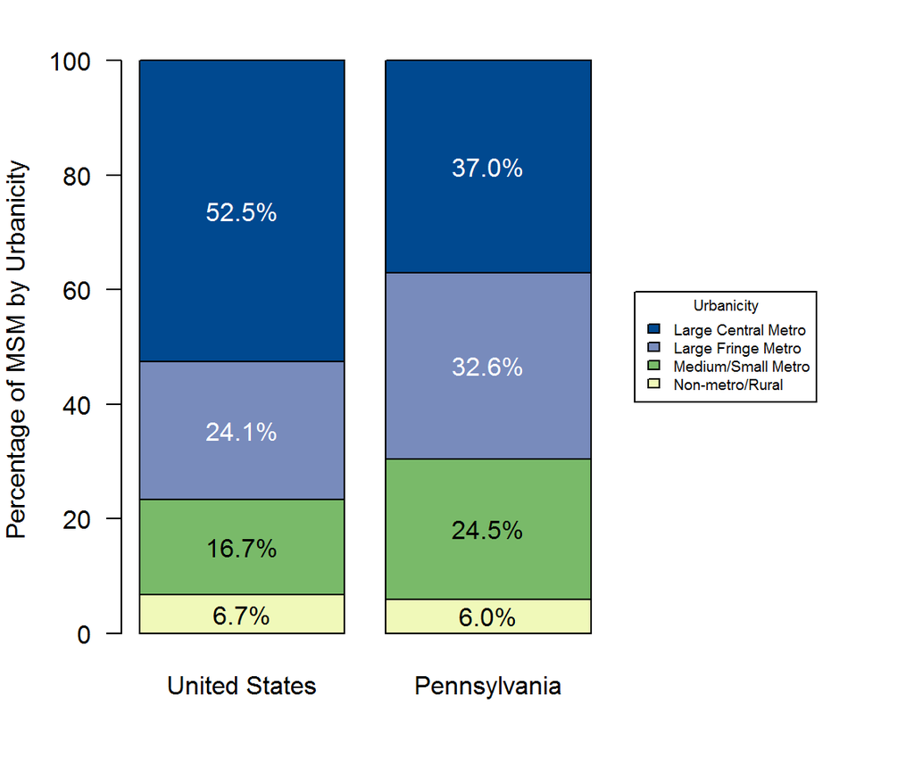

### MSM in Pennsylvania Counties

Among counties or county-equivalent areas in Pennsylvania, Philadelphia County had the largest population of MSM at 33,549, representing 20.6% of all MSM in the state. Pike County had the highest percentage of MSM among adult men in Pennsylvania at 7.2%. This was greater than the percentage for Pennsylvania as a whole, which was 3.4% of adult men.

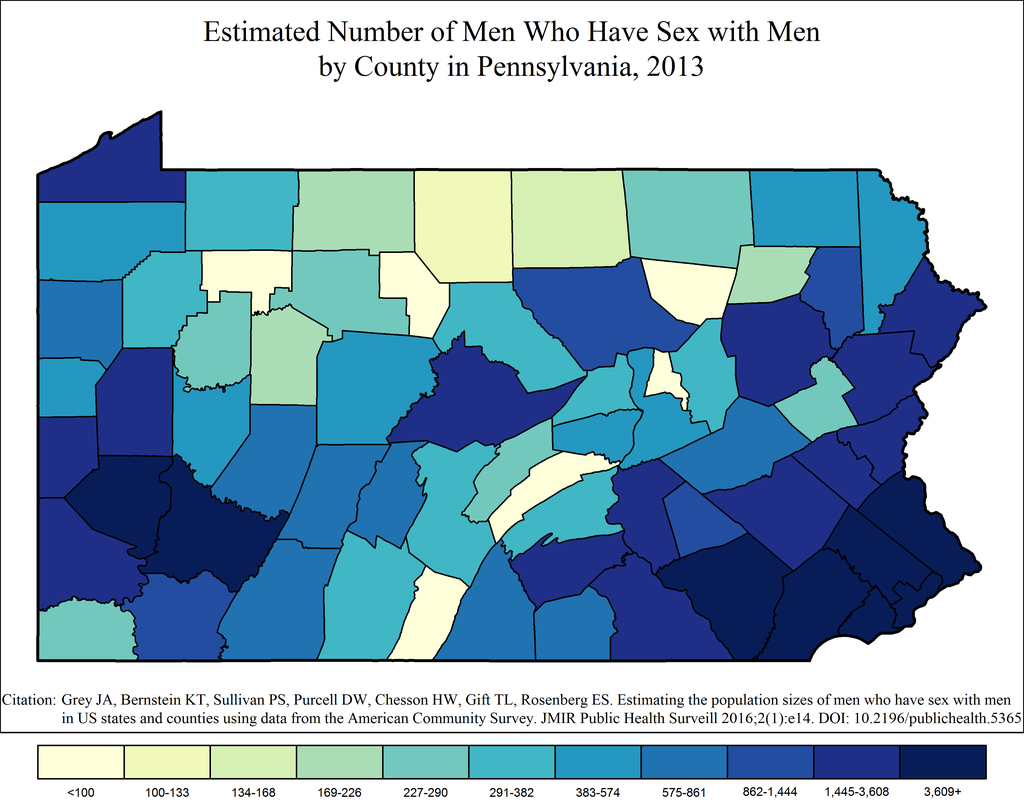

Note: Range cutpoints for the map are based on the distribution of MSM among all counties in the United States.

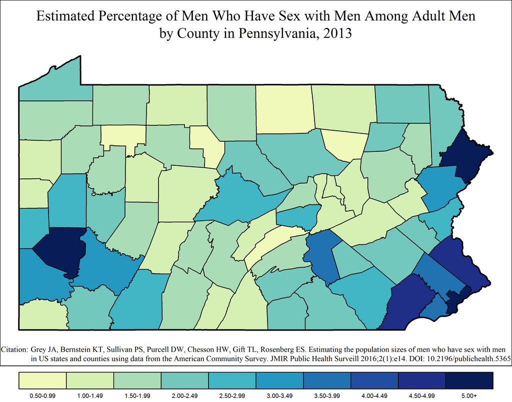

### MSM in Pennsylvania Metropolitan Statistical Areas

#### Philadelphia-Camden-Wilmington Metropolitan Statistical Area

The Philadelphia-Camden-Wilmington MSA overlaps four states: Delaware, Maryland, New Jersey and Pennsylvania. The Pennsylvania portion of the MSA had the largest metropolitan population of MSM in Pennsylvania at 72,394, or 44.5% of all MSM in the state and 72.2% of the 100,293 MSM in the MSA. Of the 1,469,540 adult men in the Pennsylvania part of Philadelphia-Camden-Wilmington, an estimated 4.9% were MSM. This was greater than the percentage of MSM among adult men in the MSA as a whole, which was 4.6% of adult men (100,293 out of 2,189,761).

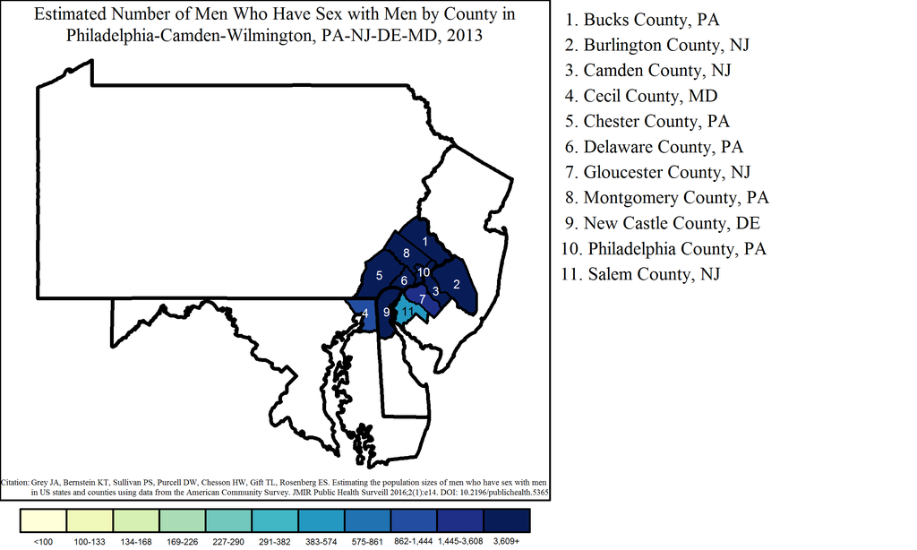

Note: Range cutpoints for the map are based on the distribution of MSM among all counties in the United States.

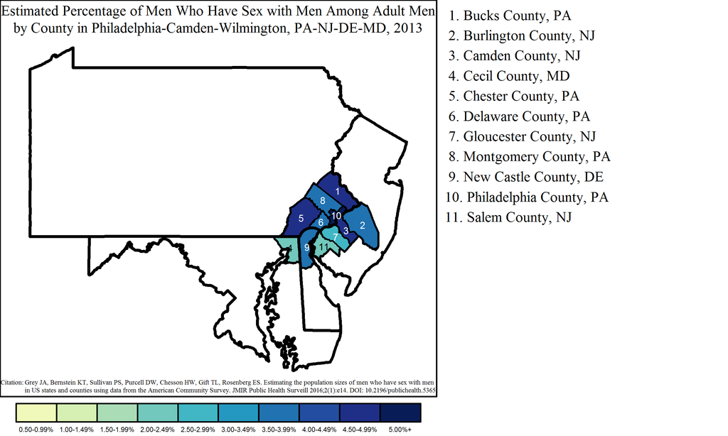

#### Pittsburgh Metropolitan Statistical Area

The Pittsburgh MSA had a population of 39,260 MSM, or 24.1% of all MSM in Pennsylvania. Of the 901,846 adult men in Pittsburgh, an estimated 4.4% were MSM.

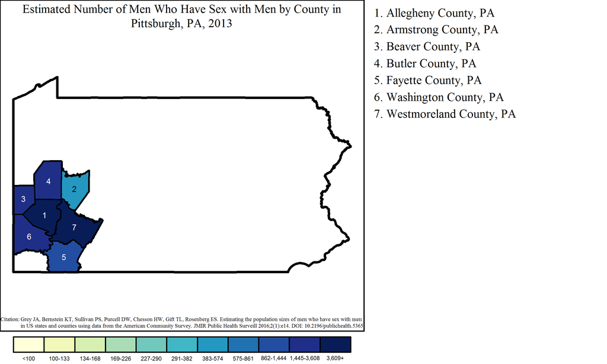

Note: Range cutpoints for the map are based on the distribution of MSM among all counties in the United States.

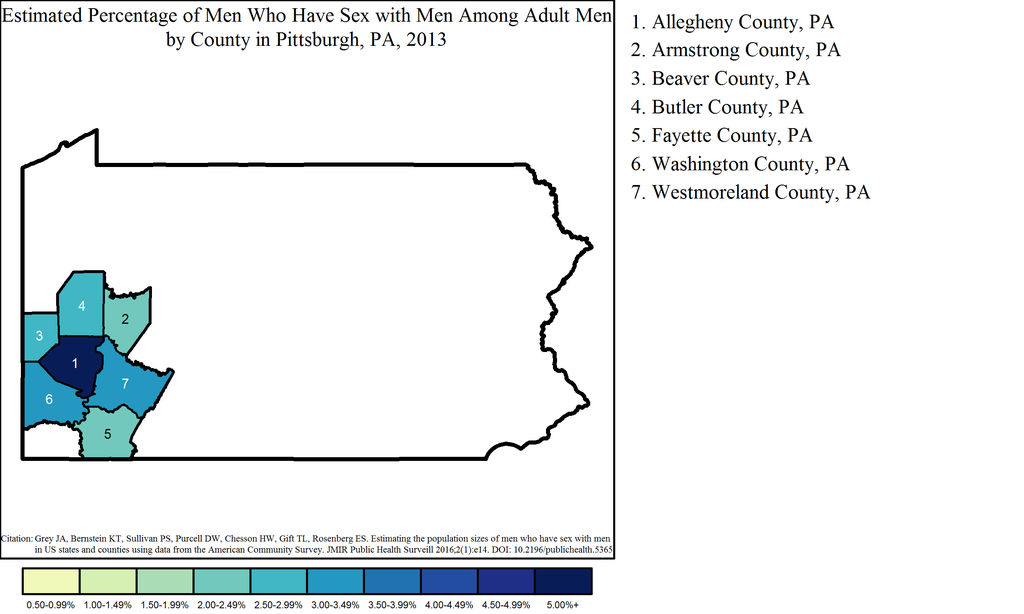

#### Allentown-Bethlehem-Easton Metropolitan Statistical Area

The Allentown-Bethlehem-Easton MSA overlaps two states: New Jersey and Pennsylvania. The Pennsylvania portion of the MSA had 5,991 MSM, or 3.7% of all MSM in the state and 91.1% of the 6,577 MSM in the MSA. Of 267,440 adult men in the Pennsylvania part of Allentown-Bethlehem-Easton, 2.2% were MSM. This was greater than the overall percentage of MSM among adult men in the MSA, which was 2.1% of adult men (6,577 out of 307,373).

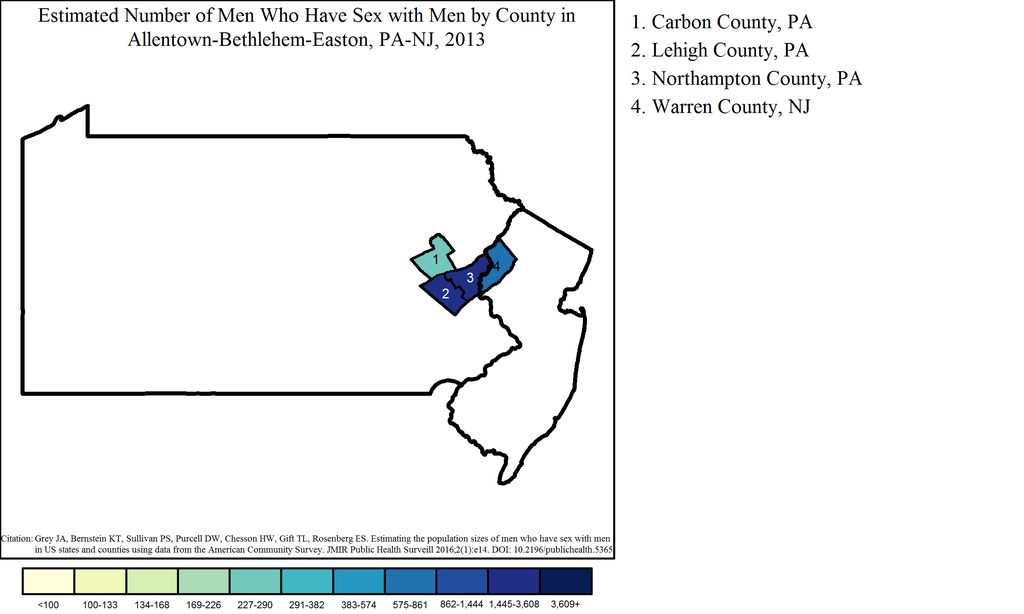

Note: Range cutpoints for the map are based on the distribution of MSM among all counties in the United States.

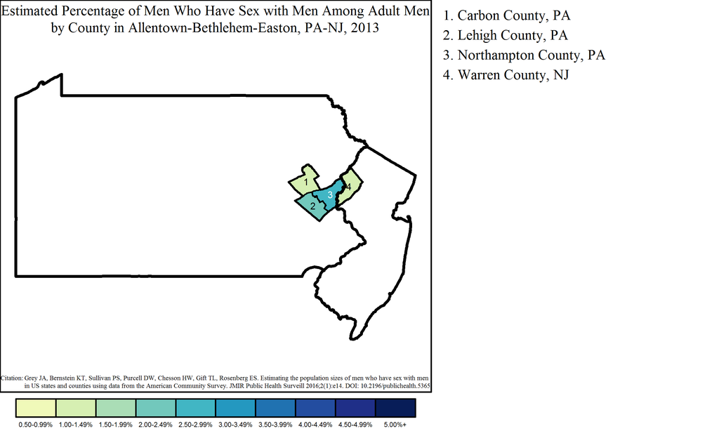

#### Harrisburg-Carlisle Metropolitan Statistical Area

The Harrisburg-Carlisle MSA had a population of 5,772 MSM, or 3.5% of all MSM in Pennsylvania. Of the 208,104 adult men in Harrisburg-Carlisle, an estimated 2.8% were MSM.

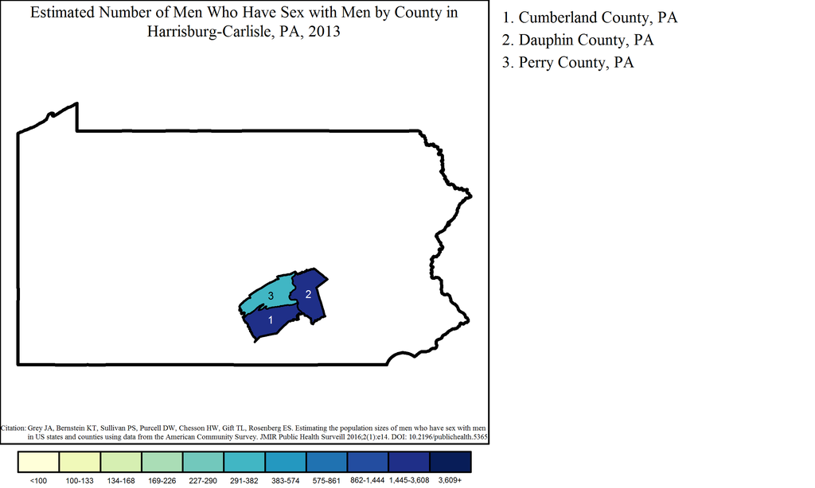

Note: Range cutpoints for the map are based on the distribution of MSM among all counties in the United States.

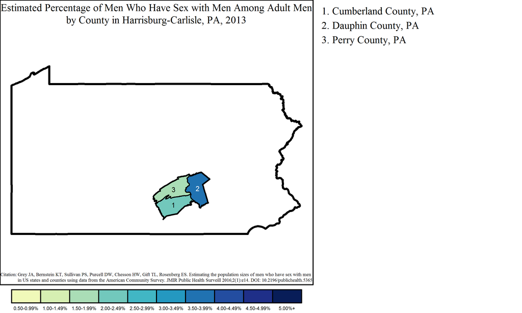

#### Lancaster Metropolitan Statistical Area

The Lancaster MSA had a population of 4,932 MSM, or 3.0% of all MSM in Pennsylvania. Of the 189,928 adult men in Lancaster, an estimated 2.6% were MSM.

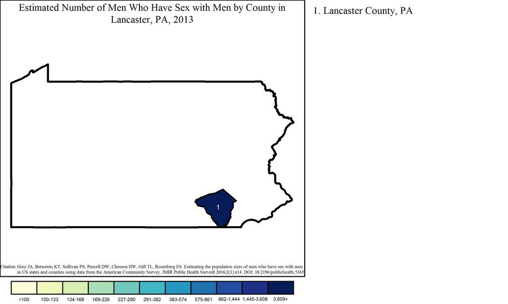

Note: Range cutpoints for the map are based on the distribution of MSM among all counties in the United States.

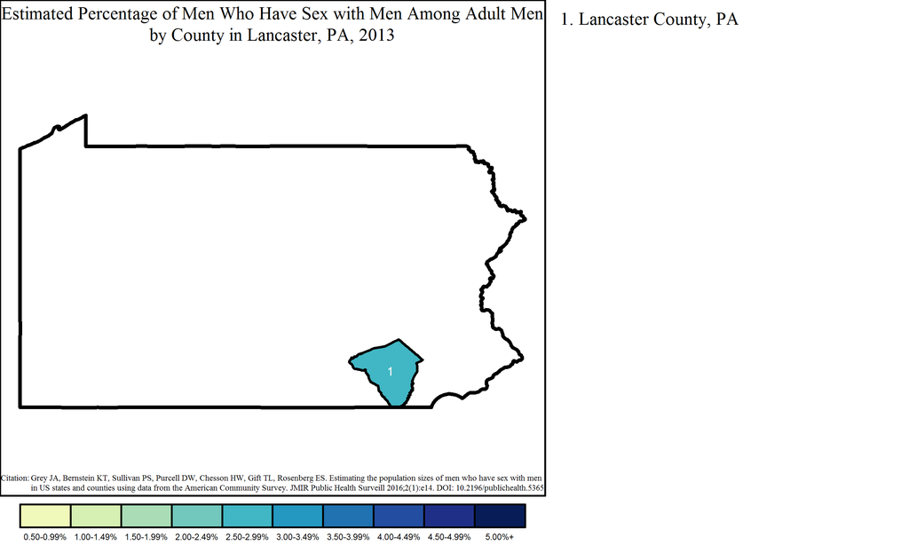

#### Scranton–Wilkes-Barre–Hazleton Metropolitan Statistical Area

The Scranton–Wilkes-Barre–Hazleton MSA had a population of 3,872 MSM, or 2.4% of all MSM in Pennsylvania. Of the 216,424 adult men in Scranton–Wilkes-Barre–Hazleton, an estimated 1.8% were MSM.

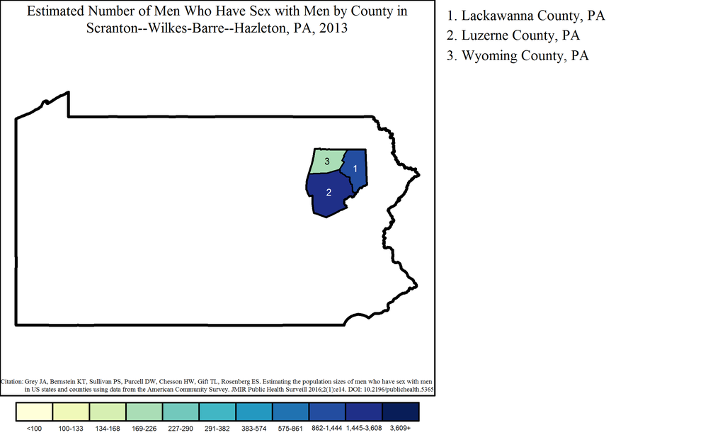

Note: Range cutpoints for the map are based on the distribution of MSM among all counties in the United States.

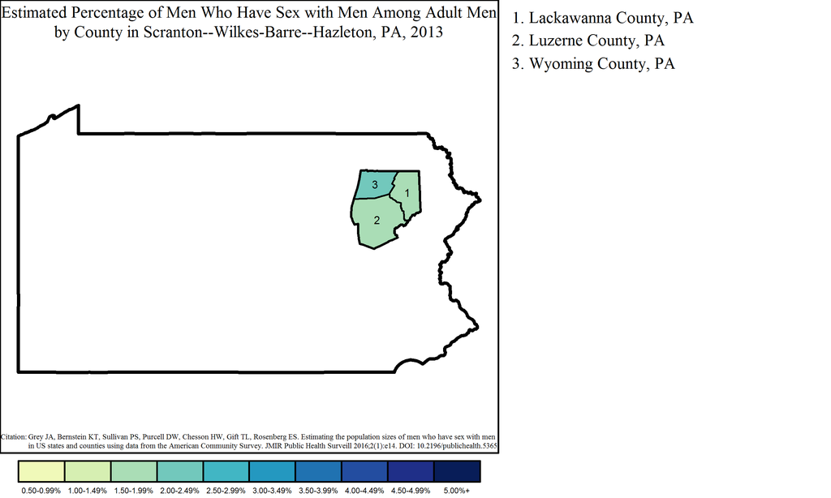

#### York-Hanover Metropolitan Statistical Area

The York-Hanover MSA had a population of 3,347 MSM, or 2.1% of all MSM in Pennsylvania. Of the 163,426 adult men in York-Hanover, an estimated 2.0% were MSM.

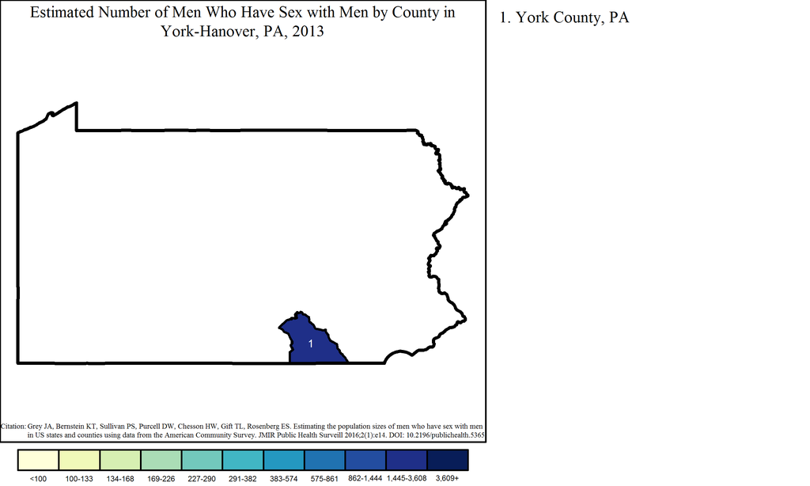

Note: Range cutpoints for the map are based on the distribution of MSM among all counties in the United States.

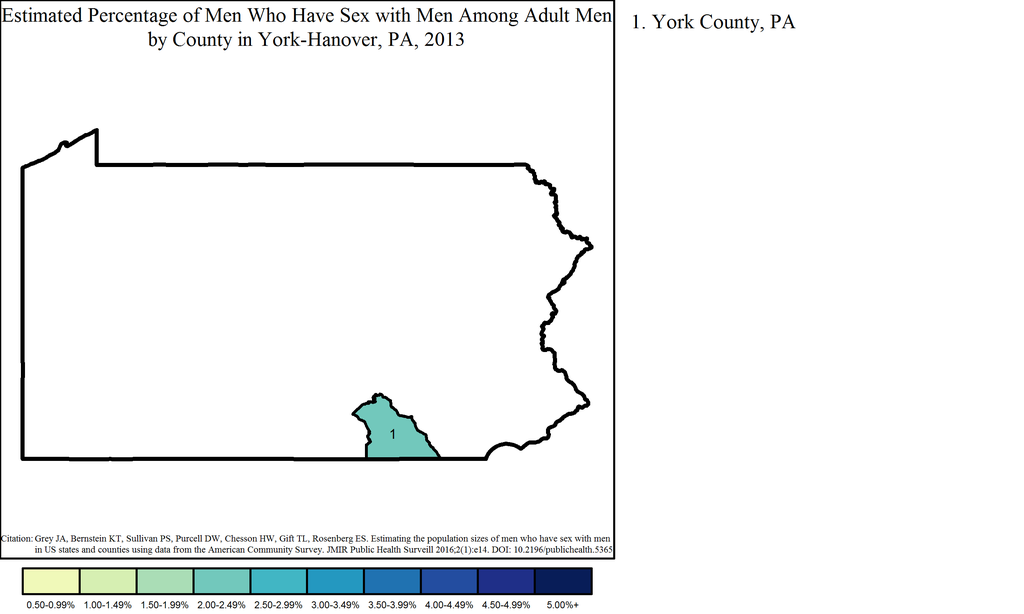

#### Reading Metropolitan Statistical Area

The Reading MSA had a population of 3,331 MSM, or 2.0% of all MSM in Pennsylvania. Of the 152,646 adult men in Reading, an estimated 2.2% were MSM.

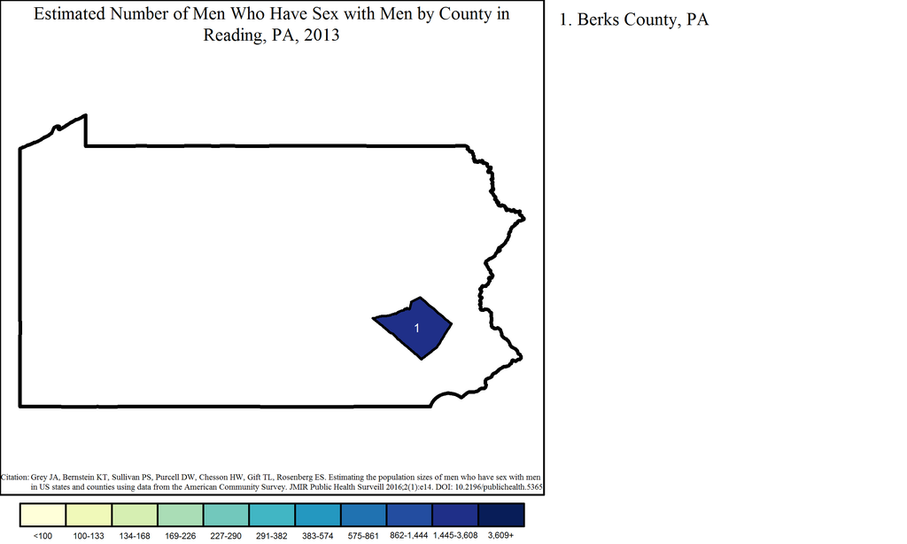

Note: Range cutpoints for the map are based on the distribution of MSM among all counties in the United States.

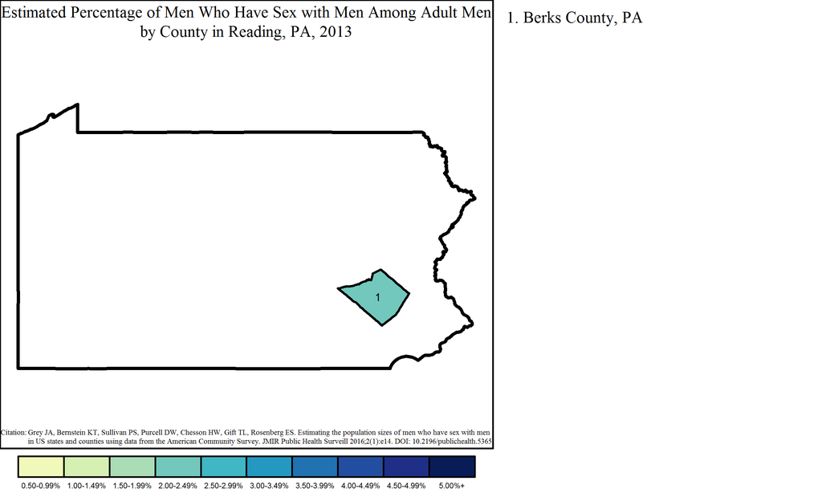

#### Erie Metropolitan Statistical Area

The Erie MSA had a population of 2,526 MSM, or 1.6% of all MSM in Pennsylvania. Of the 105,668 adult men in Erie, an estimated 2.4% were MSM.

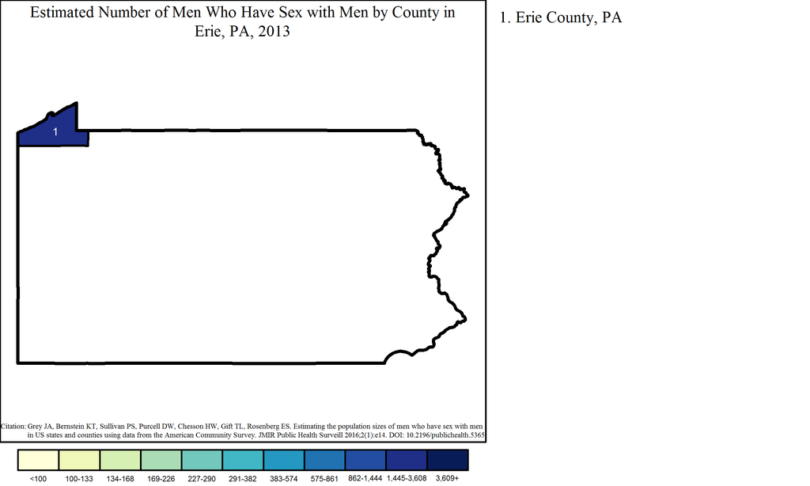

Note: Range cutpoints for the map are based on the distribution of MSM among all counties in the United States.

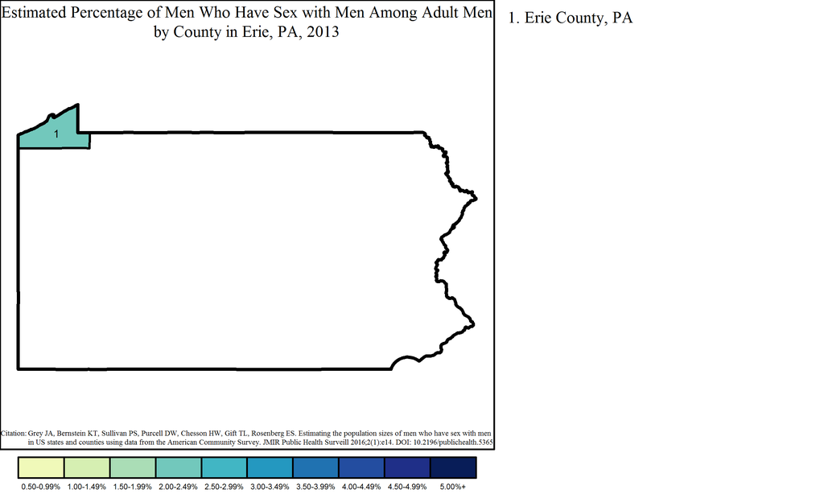

#### East Stroudsburg Metropolitan Statistical Area

The East Stroudsburg MSA had a population of 2,052 MSM, or 1.3% of all MSM in Pennsylvania. Of the 63,540 adult men in East Stroudsburg, an estimated 3.2% were MSM.

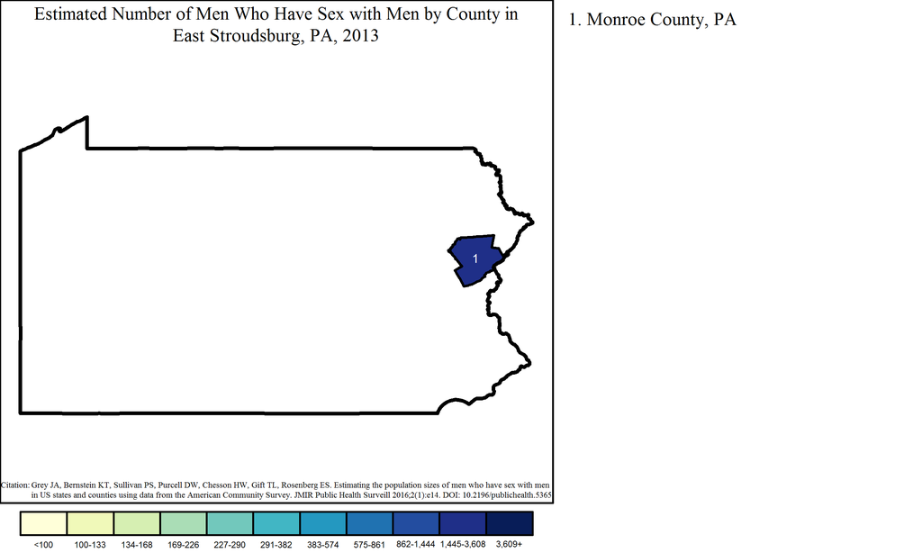

Note: Range cutpoints for the map are based on the distribution of MSM among all counties in the United States.

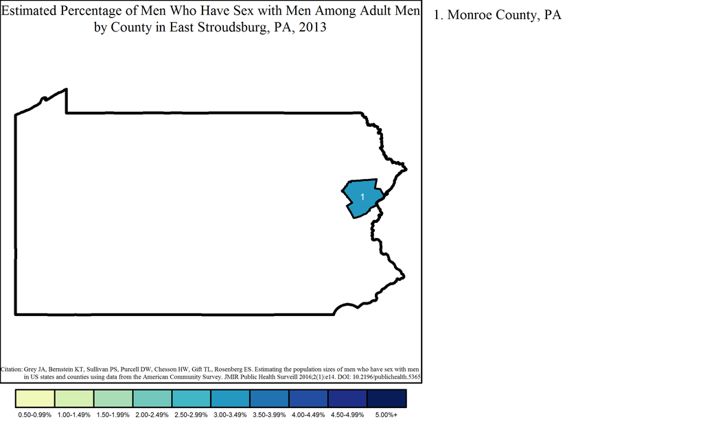

#### State College Metropolitan Statistical Area

The State College MSA had a population of 1,749 MSM, or 1.1% of all MSM in Pennsylvania. Of the 67,733 adult men in State College, an estimated 2.6% were MSM.

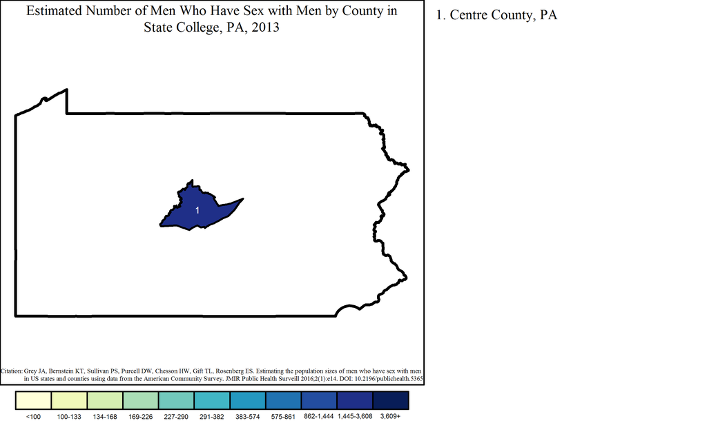

Note: Range cutpoints for the map are based on the distribution of MSM among all counties in the United States.

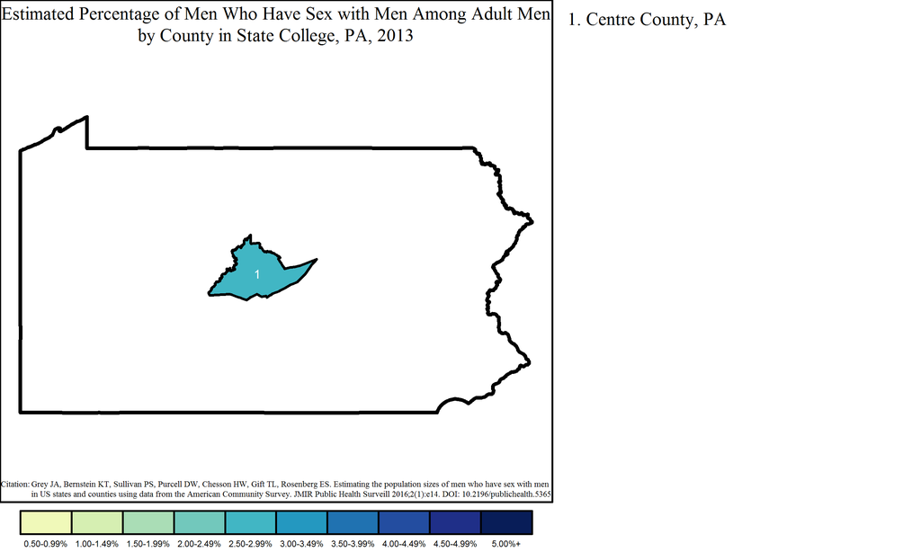

#### New York-Newark-Jersey City Metropolitan Statistical Area

The New York-Newark-Jersey City MSA overlaps three states: New Jersey, New York and Pennsylvania. The Pennsylvania portion of the MSA had 1,595 MSM, or 1.0% of all MSM in the state and 0.4% of the 397,399 MSM in the MSA. Of 22,027 adult men in the Pennsylvania part of New York-Newark-Jersey City, 7.2% were MSM. This was greater than the overall percentage of MSM among adult men in the MSA, which was 5.5% of adult men (397,399 out of 7,239,158).

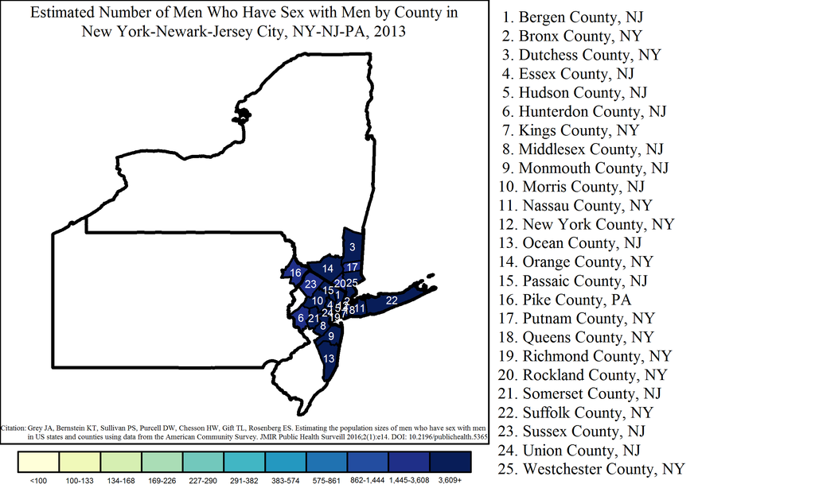

Note: Range cutpoints for the map are based on the distribution of MSM among all counties in the United States.

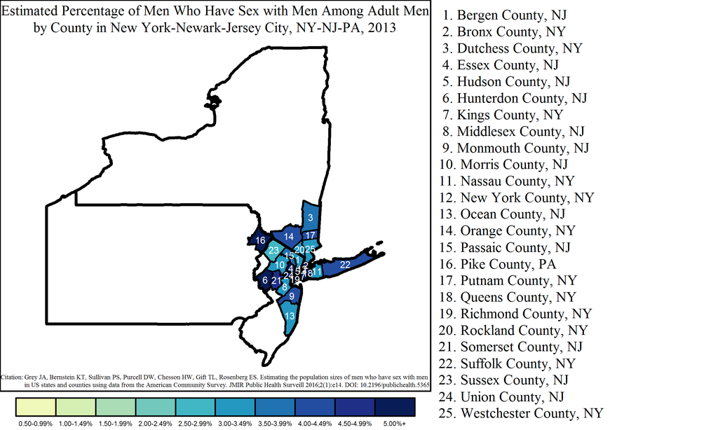

#### Lebanon Metropolitan Statistical Area

The Lebanon MSA had a population of 1,086 MSM, or 0.7% of all MSM in Pennsylvania. Of the 49,786 adult men in Lebanon, an estimated 2.2% were MSM.

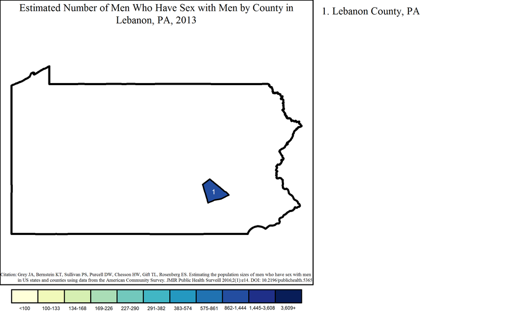

Note: Range cutpoints for the map are based on the distribution of MSM among all counties in the United States.

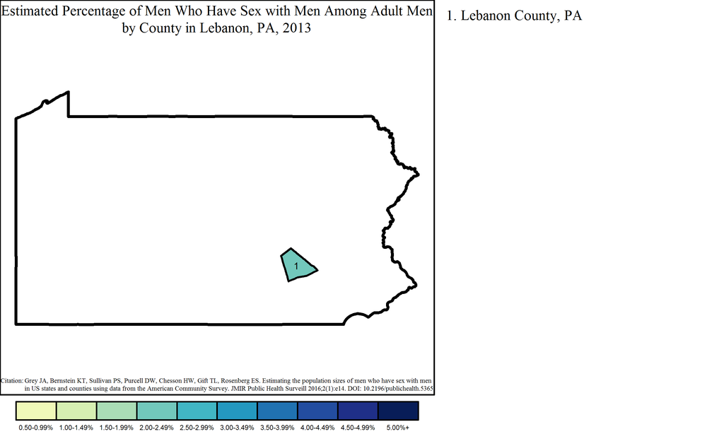

#### Williamsport Metropolitan Statistical Area

The Williamsport MSA had a population of 981 MSM, or 0.6% of all MSM in Pennsylvania. Of the 44,839 adult men in Williamsport, an estimated 2.2% were MSM.

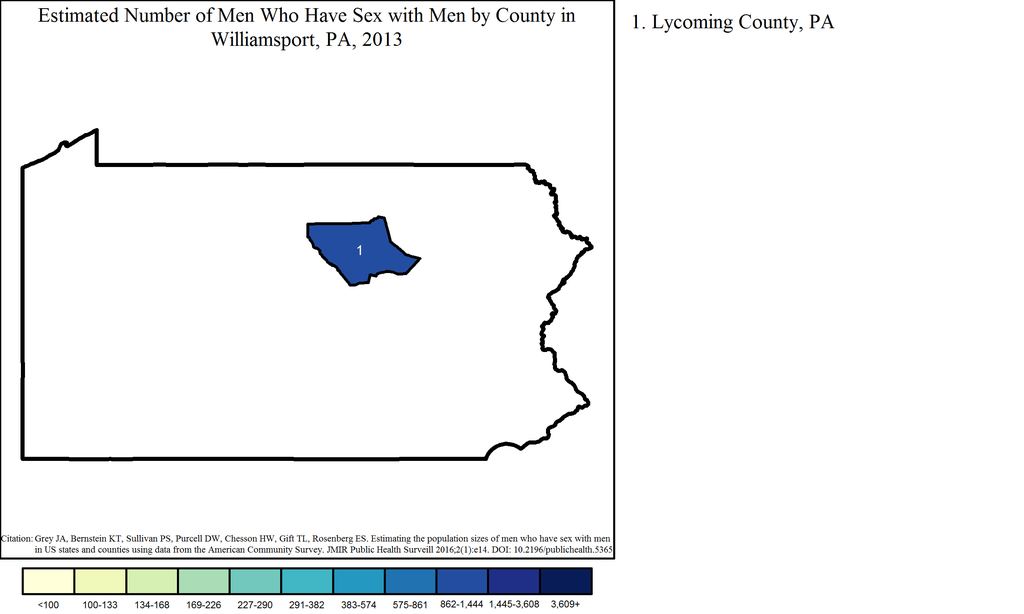

Note: Range cutpoints for the map are based on the distribution of MSM among all counties in the United States.

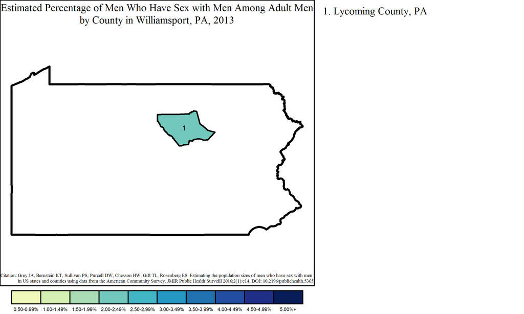